# 02- Spatial Analisis Part 2

Geospatial Analysis of the 2023 Earthquakes in Turkey  
**Master Thesis**  
**Master of Data Science**

Gozde Yazganoglu (*gozde.yazganoglu@cunef.edu*)

1. Introduction
2. Importing libraries
3. Calculation of Regional Percentages
4. Spatial Statistics and Interpretation:
5. Saving data for other notebooks

## 1. Introduction

Back to Table of Contents

In this analysis, we delve into the critical concepts of spatial autocorrelation, spatial lags, and local proportions of certain variables. Spatial autocorrelation assesses the degree to which a set of spatial features and their associated values tend to be clustered together in space or, conversely, dispersed.

Understanding spatial autocorrelation is pivotal because spatial data often violate the assumption of independence, a principle foundational to many statistical methods. Recognizing and accounting for spatial autocorrelation can help enhance the reliability of inferential statistics derived from spatial data.

Spatial lags, on the other hand, capture the influence of neighboring observations on a particular location. It's a measure designed to evaluate how specific locations relate to their neighbors, providing insights into patterns of influence and connectivity in the data.

Furthermore, by examining local percentages of specific variables, we can discern localized patterns and deviations. This granular insight can be instrumental in pinpointing areas of interest, detecting anomalies, or tailoring location-specific interventions.

Together, these spatial analysis techniques offer a comprehensive view of the spatial dynamics at play in our data. They enable us to detect patterns, correlations, and anomalies that might otherwise remain hidden, ensuring that our subsequent decisions and interpretations are grounded in a thorough understanding of the spatial relationships inherent in the data.

## 2. Importing libraries

Back to Table of Contents

Libraries will function in new_geo_env.

```python
import geopandas as gpd
import pandas as pd
import contextily as ctx
import matplotlib.pyplot as plt
from aux_func import save_data
import libpysal as lps
from esda.moran import Moran
```

```python
#reading the data
#
data = gpd.read_file('../data/processed/dataset2.geojson')

data.head()
```

|  | obj_type | info | damage_gra | locality | population | income | total_sales | second_sales | water_access | elec_cons | ... | fertility | hh_size | longitude | latitude | nearest_water_source_distance | nearest_camping_distance | nearest_earthquake_distance | nearest_fault_distance | elev | geometry |
| --- | --- | --- | --- | --- | --- | --- | --- | --- | --- | --- | --- | --- | --- | --- | --- | --- | --- | --- | --- | --- | --- |
| 0 | 11_RESIDENTIAL_BUILDINGS | 997_NOT_APPLICABLE | 1 | ADIYAMAN | 316140 | 4092 | 40087 | 20574 | 0.98 | 2060 | ... | 2.36 | 4.0 | 38.314252 | 37.768867 | 0.077874 | 0.020232 | 1.121897 | 0.016935 | 660.0 | POLYGON ((38.31461 37.76919, 38.31480 37.76871... |
| 1 | 11_RESIDENTIAL_BUILDINGS | 997_NOT_APPLICABLE | 1 | ADIYAMAN | 316140 | 4092 | 40087 | 20574 | 0.98 | 2060 | ... | 2.36 | 4.0 | 38.313284 | 37.768690 | 0.076904 | 0.019284 | 1.121020 | 0.017440 | 660.0 | POLYGON ((38.31327 37.76841, 38.31297 37.76834... |
| 2 | 12_NON_RESIDENTIAL_BUILDINGS | 1251_INDUSTRIAL_BUILDINGS | 1 | ADIYAMAN | 316140 | 4092 | 40087 | 20574 | 0.98 | 2060 | ... | 2.36 | 4.0 | 38.318013 | 37.768612 | 0.081336 | 0.023588 | 1.125574 | 0.014585 | 660.0 | POLYGON ((38.31832 37.76898, 38.31826 37.76822... |
| 3 | 12_NON_RESIDENTIAL_BUILDINGS | 1251_INDUSTRIAL_BUILDINGS | 1 | ADIYAMAN | 316140 | 4092 | 40087 | 20574 | 0.98 | 2060 | ... | 2.36 | 4.0 | 38.318677 | 37.768575 | 0.081953 | 0.024196 | 1.126222 | 0.014241 | 660.0 | POLYGON ((38.31898 37.76892, 38.31893 37.76819... |
| 4 | 11_RESIDENTIAL_BUILDINGS | 997_NOT_APPLICABLE | 1 | ADIYAMAN | 316140 | 4092 | 40087 | 20574 | 0.98 | 2060 | ... | 2.36 | 4.0 | 38.312542 | 37.768514 | 0.076146 | 0.018542 | 1.120359 | 0.017826 | 660.0 | POLYGON ((38.31286 37.76831, 38.31243 37.76819... |

5 rows × 27 columns

## 3. Calculation of Regional Percentages

Back to Table of Contents

For this study, the chosen representative metric is the percentage of buildings that have been damaged or destroyed. This specific metric is crucial because understanding the proportion of affected structures can provide insights into the severity and spatial extent of the damage, helping to tailor interventions and responses more effectively. By examining these percentages, we aim to gain a deeper understanding of the local dynamics and their implications on the broader spatial patterns of destruction.

```python
# percentage of the observed value in this local
# Count the number of buildings with each damage grade in each locality
damage_counts = data.groupby(['locality', 'damage_gra']).size().reset_index(name='count')

# Count the total number of buildings in each locality
total_counts = data.groupby('locality').size().reset_index(name='total_count')

# Merge damage counts with total counts
merged = pd.merge(damage_counts, total_counts, on='locality')

# Calculate the percentage
merged['percentage'] = (merged['count'] / merged['total_count']) * 100

# This DataFrame now contains the percentage of each damage grade for each locality
print(merged)

# Optionally, if you want to merge these percentages back to your original dataset:
data = data.merge(merged[['locality', 'damage_gra', 'percentage', ]], on=['locality', 'damage_gra'], how='left')
merged.head()
```

```
     locality  damage_gra  count  total_count  percentage
0    ADIYAMAN           1   6531         6772   96.441229
1    ADIYAMAN           2     46         6772    0.679268
2    ADIYAMAN           3    143         6772    2.111636
3    ADIYAMAN           4     52         6772    0.767868
4       AFSIN           1    655          712   91.994382
..        ...         ...    ...          ...         ...
71  SANLIURFA           3      2        11980    0.016694
72   TURKOGLU           1    433          485   89.278351
73   TURKOGLU           2     18          485    3.711340
74   TURKOGLU           3     25          485    5.154639
75   TURKOGLU           4      9          485    1.855670

[76 rows x 5 columns]
```

|  | locality | damage_gra | count | total_count | percentage |
| --- | --- | --- | --- | --- | --- |
| 0 | ADIYAMAN | 1 | 6531 | 6772 | 96.441229 |
| 1 | ADIYAMAN | 2 | 46 | 6772 | 0.679268 |
| 2 | ADIYAMAN | 3 | 143 | 6772 | 2.111636 |
| 3 | ADIYAMAN | 4 | 52 | 6772 | 0.767868 |
| 4 | AFSIN | 1 | 655 | 712 | 91.994382 |

Buildings that have been destroyed likely require demolition and may have resulted in injuries or loss of life. Regrettably, we lack specific data on any potential casualties. Conversely, buildings with other degrees of damage, while perhaps not life-threatening at the onset, carry significant economic implications. Such structures necessitate either complete replacement or extensive renovations to reinforce their integrity. Even if these buildings didn't initially pose a threat to human safety, their current condition could present imminent risks, making prompt action essential. The importance of addressing these damaged buildings not only stems from safety concerns but also from the economic strain they place on communities, as they represent lost assets and potential future liabilities. Therfore, we are interested to know these percentages as well.

```python
#Calculation of Destroyed Buildings Percentage per Locality

# Filter buildings that are destroyed
destroyed = data[data['damage_gra'] == 4]

# Count the number of destroyed buildings per locality
destroyed_counts = destroyed.groupby('locality').size().reset_index(name='destroyed_count')

# Count the total number of buildings in each locality
total_counts = data.groupby('locality').size().reset_index(name='total_count')

# Merge counts
merged = pd.merge(total_counts, destroyed_counts, on='locality', how='left').fillna(0)

# Calculate the percentage
merged['destroyed_percentage'] = (merged['destroyed_count'] / merged['total_count']) * 100
```

```python
# Filter buildings with damage_gra of 2, 3, or 4
damaged = data[data['damage_gra'].isin([2, 3, 4])]

# Count the number of these buildings per locality
damaged_counts = damaged.groupby('locality').size().reset_index(name='damaged_count')

# Merge this count with total_counts to get the percentage
percentage_df = pd.merge(total_counts, damaged_counts, on='locality', how='left').fillna(0)

# Calculate the percentage
percentage_df['damaged_percentage'] = (percentage_df['damaged_count'] / percentage_df['total_count']) * 100

# Merge the damaged_percentage back to the original dataframe
data = data.merge(percentage_df[['locality', 'damaged_percentage']], on='locality', how='left')
```

```python
# Merge the destroyed_percentage back to the original dataframe
data = data.merge(merged[['locality', 'destroyed_percentage']], on='locality', how='left')


data.dropna(inplace=True)
```

```python
# in order to graph we need to transform the data to a different projection
import rasterio
data.to_crs(epsg=3857)
```

|  | obj_type | info | damage_gra | locality | population | income | total_sales | second_sales | water_access | elec_cons | ... | latitude | nearest_water_source_distance | nearest_camping_distance | nearest_earthquake_distance | nearest_fault_distance | elev | geometry | percentage | damaged_percentage | destroyed_percentage |
| --- | --- | --- | --- | --- | --- | --- | --- | --- | --- | --- | --- | --- | --- | --- | --- | --- | --- | --- | --- | --- | --- |
| 0 | 11_RESIDENTIAL_BUILDINGS | 997_NOT_APPLICABLE | 1 | ADIYAMAN | 316140 | 4092 | 40087 | 20574 | 0.98 | 2060 | ... | 37.768867 | 0.077874 | 0.020232 | 1.121897 | 0.016935 | 660.0 | POLYGON ((4265163.381 4546871.567, 4265183.651... | 96.441229 | 3.558771 | 0.767868 |
| 1 | 11_RESIDENTIAL_BUILDINGS | 997_NOT_APPLICABLE | 1 | ADIYAMAN | 316140 | 4092 | 40087 | 20574 | 0.98 | 2060 | ... | 37.768690 | 0.076904 | 0.019284 | 1.121020 | 0.017440 | 660.0 | POLYGON ((4265013.896 4546760.918, 4264980.052... | 96.441229 | 3.558771 | 0.767868 |
| 2 | 12_NON_RESIDENTIAL_BUILDINGS | 1251_INDUSTRIAL_BUILDINGS | 1 | ADIYAMAN | 316140 | 4092 | 40087 | 20574 | 0.98 | 2060 | ... | 37.768612 | 0.081336 | 0.023588 | 1.125574 | 0.014585 | 660.0 | POLYGON ((4265575.379 4546841.461, 4265569.239... | 96.441229 | 3.558771 | 0.767868 |
| 3 | 12_NON_RESIDENTIAL_BUILDINGS | 1251_INDUSTRIAL_BUILDINGS | 1 | ADIYAMAN | 316140 | 4092 | 40087 | 20574 | 0.98 | 2060 | ... | 37.768575 | 0.081953 | 0.024196 | 1.126222 | 0.014241 | 660.0 | POLYGON ((4265649.791 4546833.519, 4265643.726... | 96.441229 | 3.558771 | 0.767868 |
| 4 | 11_RESIDENTIAL_BUILDINGS | 997_NOT_APPLICABLE | 1 | ADIYAMAN | 316140 | 4092 | 40087 | 20574 | 0.98 | 2060 | ... | 37.768514 | 0.076146 | 0.018542 | 1.120359 | 0.017826 | 660.0 | POLYGON ((4264968.014 4546747.790, 4264920.190... | 96.441229 | 3.558771 | 0.767868 |
| ... | ... | ... | ... | ... | ... | ... | ... | ... | ... | ... | ... | ... | ... | ... | ... | ... | ... | ... | ... | ... | ... |
| 98790 | 212_RAILWAYS | 997_NOT_APPLICABLE | 1 | TURKOGLU | 78976 | 5997 | 1938 | 536 | 0.95 | 4343 | ... | 37.371851 | 0.194512 | 0.012611 | 0.091935 | 0.031609 | 500.0 | LINESTRING (4102248.374 4490463.471, 4102329.2... | 89.278351 | 10.721649 | 1.855670 |
| 98791 | 212_RAILWAYS | 997_NOT_APPLICABLE | 1 | TURKOGLU | 78976 | 5997 | 1938 | 536 | 0.95 | 4343 | ... | 37.371509 | 0.194789 | 0.013011 | 0.091542 | 0.031945 | 500.0 | LINESTRING (4102329.277 4490527.334, 4102465.7... | 89.278351 | 10.721649 | 1.855670 |
| 98792 | 212_RAILWAYS | 997_NOT_APPLICABLE | 1 | TURKOGLU | 78976 | 5997 | 1938 | 536 | 0.95 | 4343 | ... | 37.371981 | 0.194226 | 0.012857 | 0.091609 | 0.031466 | 500.0 | LINESTRING (4102451.884 4490616.207, 4102518.7... | 89.278351 | 10.721649 | 1.855670 |
| 98793 | 212_RAILWAYS | 997_NOT_APPLICABLE | 1 | TURKOGLU | 78976 | 5997 | 1938 | 536 | 0.95 | 4343 | ... | 37.372028 | 0.194388 | 0.012364 | 0.092188 | 0.031438 | 500.0 | LINESTRING (4102329.277 4490527.334, 4102396.6... | 89.278351 | 10.721649 | 1.855670 |
| 98794 | 212_RAILWAYS | 997_NOT_APPLICABLE | 1 | TURKOGLU | 78976 | 5997 | 1938 | 536 | 0.95 | 4343 | ... | 37.372203 | 0.194252 | 0.012148 | 0.092403 | 0.031268 | 500.0 | LINESTRING (4102329.277 4490527.334, 4102396.0... | 89.278351 | 10.721649 | 1.855670 |

98795 rows × 30 columns

Apert from percentages, we would like to also know how other distances we have created are distributed in the area.

```python
percentage_columns = ['percentage', 'damaged_percentage', 'destroyed_percentage','nearest_water_source_distance',
                      'nearest_camping_distance',	'nearest_earthquake_distance',	'nearest_fault_distance', 'damage_gra']
```

[figure not shown]

```python
# Create a 3x1 grid of subplots (for three plots)
f, axes = plt.subplots(8, 1, figsize=(9, 27))  # Adjusted figsize for three plots



for ax, column in zip(axes, percentage_columns):
    data.plot(
        column=column,
        cmap="viridis",
        scheme="quantiles",
        k=5,
        edgecolor="white",
        linewidth=0.0,
        alpha=0.75,
        legend=True,
        legend_kwds={"loc": 2},
        ax=ax,
    )

    ctx.add_basemap(
        ax,
        crs=data.crs,
        source=ctx.providers.Stamen.TerrainBackground,
    )


    ax.set_title(column)  # Setting title for each subplot

plt.tight_layout()  # Adjusts the plots so that they don't overlap
plt.show()
```

## 4. Spatial Statistics and Interpretation:

Moran's I statistic is a measure of spatial autocorrelation. In simpler terms, it gauges whether nearby locations (in space) display similar values, more so than would be expected under spatial randomness. If values at nearby locations are more similar (or more dissimilar) than what we would expect under spatial randomness, then the data exhibits spatial autocorrelation.

Here's how Moran's I works:

1. **Concept**: Moran’s I statistic compares the value of a certain attribute in one location to the average of that attribute in neighboring locations.
2. **Calculation**: Moran’s I is given by:

$$ I = \frac{n}{\sum_i \sum_j w_{ij}} \frac{\sum_i \sum_j w_{ij} (x_i - \bar{x})(x_j - \bar{x})}{\sum_i (x_i - \bar{x})^2} $$

- ( n ) is the number of spatial units.
- ( x ) is the variable of interest.
- ( \bar{x} ) is the mean of ( x ).
- ( w_{ij} ) is a spatial weight between observation ( i ) and observation ( j ).
- ( I ) close to +1 indicates positive spatial autocorrelation: high values are near high values, or low values are near low values.
- ( I ) close to -1 indicates negative spatial autocorrelation: high values are near low values and vice versa.
- ( I ) close to 0 indicates no spatial autocorrelation: spatial distribution of the values is random.
4. **Statistical Significance**: The significance of Moran's I can be tested using permutations. The idea is to compute a reference distribution of I values that would be obtained under spatial randomness. If the observed Moran's I is very different from this reference distribution, it suggests the observed pattern is not due to random chance.
5. **Spatial Weights Matrix**: Central to Moran’s I is the concept of a spatial weights matrix. This matrix defines the "neighbors" for each observation. A weight matrix can be based on contiguity (like if polygons share a common border) or distance (like observations within a certain radius).
6. **Importance in Spatial Analysis**: Moran's I is vital for detecting patterns in spatial data. Before diving deep into spatial regression or other spatial analyses, it's good practice to check for spatial autocorrelation using Moran's I. If spatial autocorrelation exists and is not accounted for, it can lead to biased or misleading results.

In essence, Moran's I is a tool that helps in understanding the spatial structure in data. If values of a certain attribute are influenced by their spatial location, Moran's I is a way to quantify and test that influence.

```python
# Creating a contiguity-based weight (Queen style by default)
w = lps.weights.KNN.from_dataframe(data, k=5)  # for 5-nearest neighbors

w.transform = 'r'  # Row-standardize the weights



results = []

for column in percentage_columns:
    y = data[column]
    moran = Moran(y, w)

    results.append({
        'Column': column,
        'Moran\'s I': moran.I,
        'Expected I': moran.EI,
        'p-value': moran.p_sim
    })

df_results = pd.DataFrame(results)
```

```python
print(df_results)
```

```
                          Column  Moran's I  Expected I  p-value
0                     percentage   0.658767    -0.00001    0.001
1             damaged_percentage   1.000000    -0.00001    0.001
2           destroyed_percentage   1.000000    -0.00001    0.001
3  nearest_water_source_distance   0.999846    -0.00001    0.001
4       nearest_camping_distance   1.000024    -0.00001    0.001
5    nearest_earthquake_distance   1.000005    -0.00001    0.001
6         nearest_fault_distance   0.999976    -0.00001    0.001
7                     damage_gra   0.532654    -0.00001    0.001
```

```
Moran's I:
```

This is the value of the Moran's I statistic for that particular variable. The Moran's I statistic measures spatial autocorrelation in a variable. A value of +1 indicates perfect positive spatial autocorrelation, 0 indicates no spatial autocorrelation, and -1 indicates perfect negative spatial autocorrelation.

For instance, the percentage column has a Moran's I of 0.658767, indicating a moderately strong positive spatial autocorrelation.

Variables like damaged_percentage, destroyed_percentage, nearest_camping_distance, and so on have a Moran's I close to 1. This suggests very strong positive spatial autocorrelation: similar values are clustered together in space.

```
Expected I:
```

This is the expected value of Moran's I under the null hypothesis of no spatial autocorrelation. In most scenarios with large datasets, this value is close to zero. Here it's -0.00001, which is effectively zero.

```
p-value:
```

This indicates the statistical significance of the observed Moran's I value against the null hypothesis of no spatial autocorrelation. A small p-value (commonly below 0.05) suggests that the observed spatial pattern is very unlikely to be the result of random chance. All the p-values in our results are 0.001, which is below the conventional significance level of 0.05. This suggests that the observed Moran's I values for all these columns are statistically significant. In other words, for all these variables, there's a very low likelihood that the spatial patterns we are seeing in the data are due to random chance.

Interpretation:

The provided results strongly suggest that all the variables in the dataset exhibit significant spatial autocorrelation. For instance:

```
damage_gra:
```

There's moderate positive spatial autocorrelation. Areas with high (or low) values for damage_gra are more likely to be surrounded by areas with similarly high (or low) values.

```
damaged_percentage, destroyed_percentage, nearest_camping_distance, nearest_earthquake_distance, nearest_fault_distance:
```

These variables display very strong positive spatial autocorrelation. Regions with high values for these variables are very likely to be surrounded by regions with similarly high values.

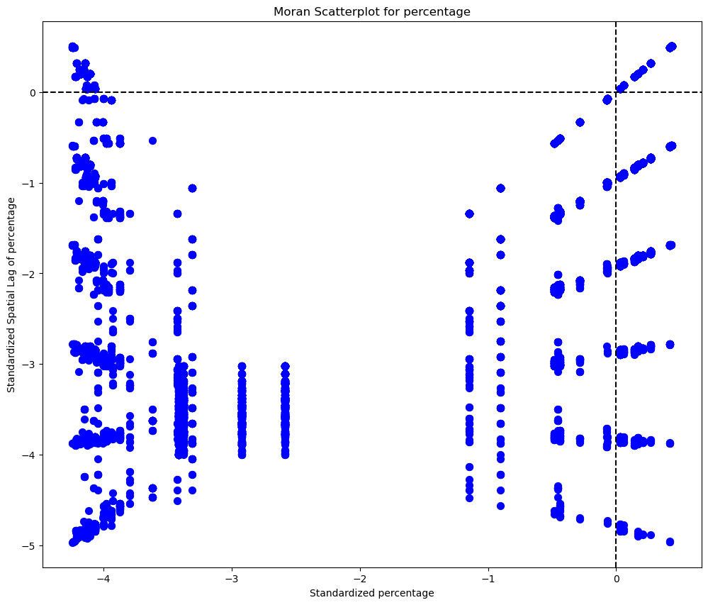

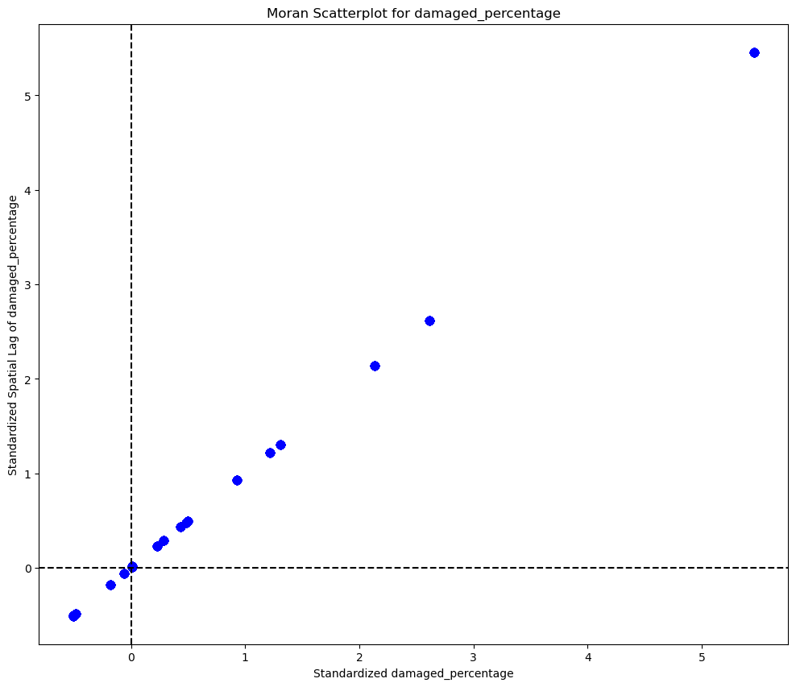

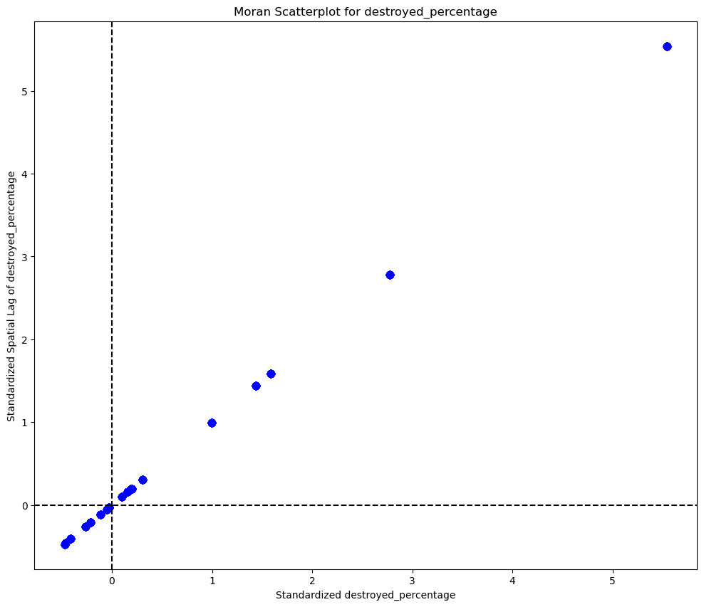

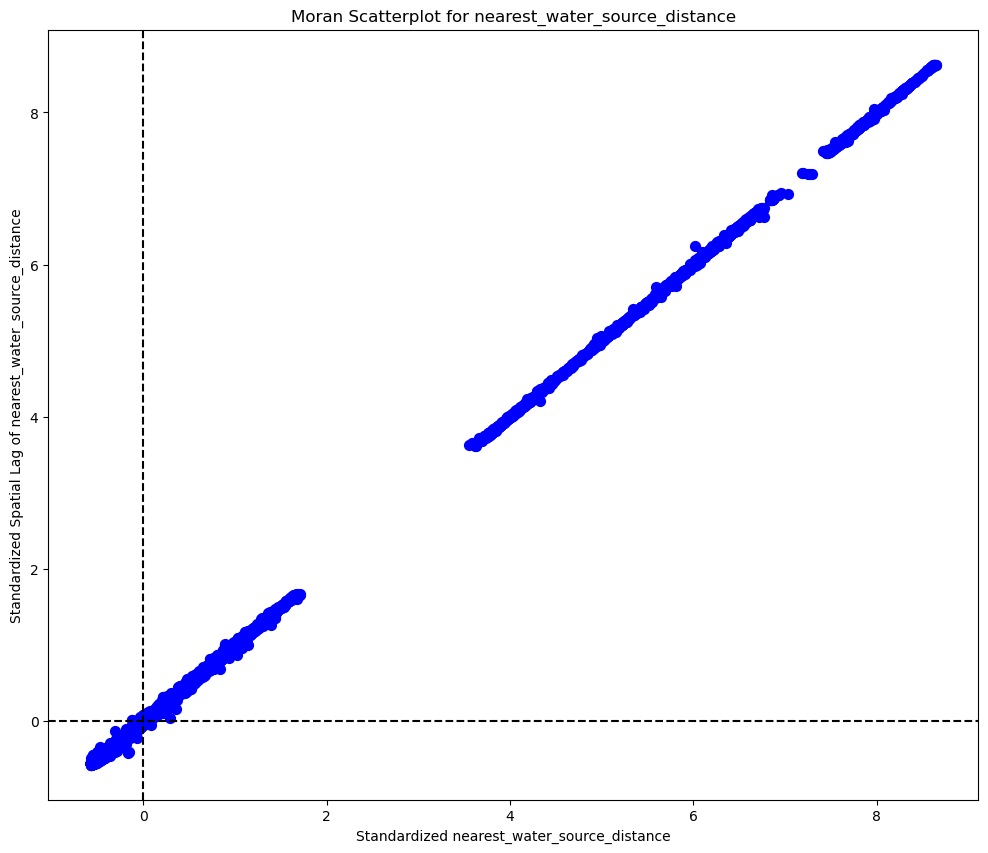

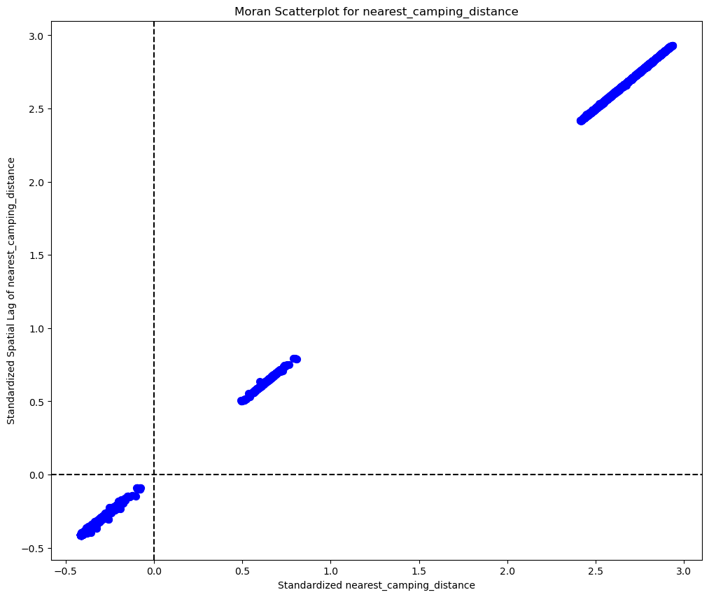

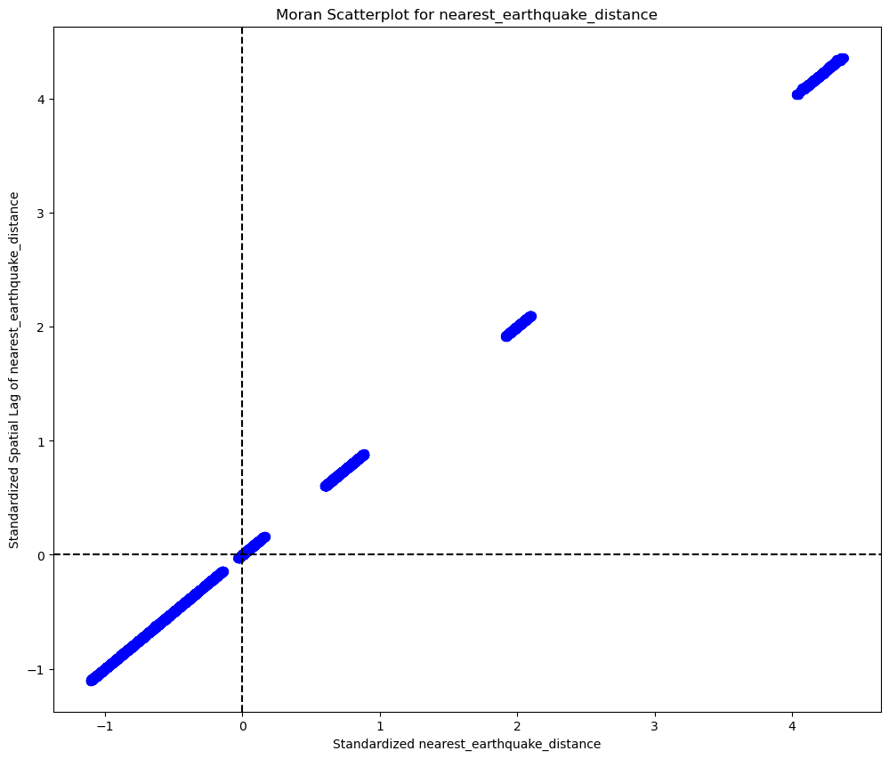

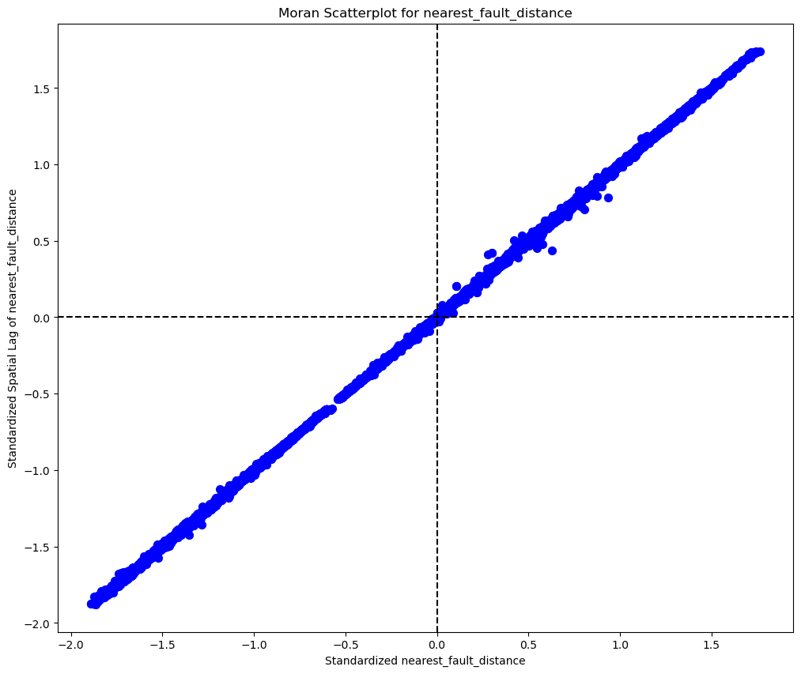

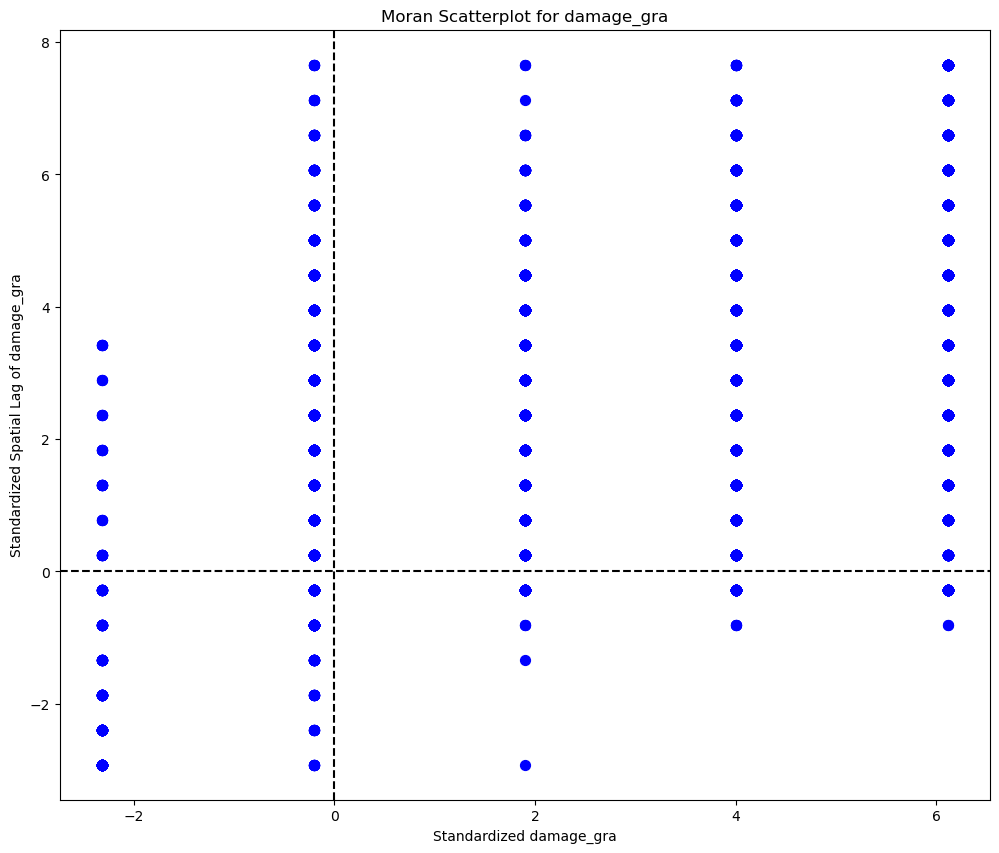

```python
# Function to plot Moran Scatterplot for a given column
def plot_moran_scatter(data, column, w):
    # Calculate the spatial lag
    data[f'lag_{column}'] = lps.weights.lag_spatial(w, data[column])

    # Standardize the column
    data[f'std_{column}'] = (data[column] - data[column].mean()) / data[column].std()

    # Standardize the spatial lag
    data[f'std_lag_{column}'] = (data[f'lag_{column}'] - data[f'lag_{column}'].mean()) / data[f'lag_{column}'].std()

    # Plot
    fig, ax = plt.subplots(figsize=(12, 10))
    plt.scatter(data[f'std_{column}'], data[f'std_lag_{column}'], color='blue', s=50)
    plt.axvline(0, color='black', linestyle='--')
    plt.axhline(0, color='black', linestyle='--')
    plt.title(f"Moran Scatterplot for {column}")
    plt.xlabel(f"Standardized {column}")
    plt.ylabel(f"Standardized Spatial Lag of {column}")
    plt.show()

percentage_columns = ['percentage', 'damaged_percentage', 'destroyed_percentage','nearest_water_source_distance',
                      'nearest_camping_distance',	'nearest_earthquake_distance',	'nearest_fault_distance', 'damage_gra']

# Generate Moran Scatterplots for each column
for col in percentage_columns:
    plot_moran_scatter(data, col, w)
```

The graphical visualization offers a deeper understanding of our dataset's underlying structure. One observation suggests that there might be duplicate or highly similar data entries. This could potentially be attributed to the fact that the damage_gra variable is ordinal, implying it can only assume a certain set of distinct values. Consequently, this might lead to the appearance of vertical groupings in the scatterplot. Additionally, the clustering pattern observed in the data indicates that there's a regional aspect at play; areas with comparable characteristics or distances tend to exhibit similar damage metrics. Such spatial tendencies emphasize the importance of considering geographic context when analyzing the data.

```python
data
```

|  | obj_type | info | damage_gra | locality | population | income | total_sales | second_sales | water_access | elec_cons | ... | std_lag_nearest_camping_distance | lag_nearest_earthquake_distance | std_nearest_earthquake_distance | std_lag_nearest_earthquake_distance | lag_nearest_fault_distance | std_nearest_fault_distance | std_lag_nearest_fault_distance | lag_damage_gra | std_damage_gra | std_lag_damage_gra |
| --- | --- | --- | --- | --- | --- | --- | --- | --- | --- | --- | --- | --- | --- | --- | --- | --- | --- | --- | --- | --- | --- |
| 0 | 11_RESIDENTIAL_BUILDINGS | 997_NOT_APPLICABLE | 1 | ADIYAMAN | 316140 | 4092 | 40087 | 20574 | 0.98 | 2060 | ... | -0.336509 | 1.121437 | 0.823108 | 0.822247 | 0.017026 | -1.708649 | -1.707721 | 1.0 | -0.208399 | -0.2745 |
| 1 | 11_RESIDENTIAL_BUILDINGS | 997_NOT_APPLICABLE | 1 | ADIYAMAN | 316140 | 4092 | 40087 | 20574 | 0.98 | 2060 | ... | -0.338395 | 1.121020 | 0.821473 | 0.821468 | 0.017263 | -1.703229 | -1.705170 | 1.0 | -0.208399 | -0.2745 |
| 2 | 12_NON_RESIDENTIAL_BUILDINGS | 1251_INDUSTRIAL_BUILDINGS | 1 | ADIYAMAN | 316140 | 4092 | 40087 | 20574 | 0.98 | 2060 | ... | -0.319254 | 1.126003 | 0.829966 | 0.830761 | 0.014187 | -1.733850 | -1.738174 | 1.0 | -0.208399 | -0.2745 |
| 3 | 12_NON_RESIDENTIAL_BUILDINGS | 1251_INDUSTRIAL_BUILDINGS | 1 | ADIYAMAN | 316140 | 4092 | 40087 | 20574 | 0.98 | 2060 | ... | -0.318057 | 1.126158 | 0.831173 | 0.831050 | 0.014298 | -1.737541 | -1.736986 | 1.0 | -0.208399 | -0.2745 |
| 4 | 11_RESIDENTIAL_BUILDINGS | 997_NOT_APPLICABLE | 1 | ADIYAMAN | 316140 | 4092 | 40087 | 20574 | 0.98 | 2060 | ... | -0.339910 | 1.120674 | 0.820239 | 0.820823 | 0.017477 | -1.699083 | -1.702874 | 1.0 | -0.208399 | -0.2745 |
| ... | ... | ... | ... | ... | ... | ... | ... | ... | ... | ... | ... | ... | ... | ... | ... | ... | ... | ... | ... | ... | ... |
| 98790 | 212_RAILWAYS | 997_NOT_APPLICABLE | 1 | TURKOGLU | 78976 | 5997 | 1938 | 536 | 0.95 | 4343 | ... | -0.364657 | 0.092105 | -1.097597 | -1.097274 | 0.031475 | -1.551232 | -1.552713 | 1.0 | -0.208399 | -0.2745 |
| 98791 | 212_RAILWAYS | 997_NOT_APPLICABLE | 1 | TURKOGLU | 78976 | 5997 | 1938 | 536 | 0.95 | 4343 | ... | -0.364976 | 0.092183 | -1.098330 | -1.097127 | 0.031408 | -1.547625 | -1.553434 | 1.0 | -0.208399 | -0.2745 |
| 98792 | 212_RAILWAYS | 997_NOT_APPLICABLE | 1 | TURKOGLU | 78976 | 5997 | 1938 | 536 | 0.95 | 4343 | ... | -0.364853 | 0.092170 | -1.098204 | -1.097152 | 0.031503 | -1.552762 | -1.552407 | 1.0 | -0.208399 | -0.2745 |
| 98793 | 212_RAILWAYS | 997_NOT_APPLICABLE | 1 | TURKOGLU | 78976 | 5997 | 1938 | 536 | 0.95 | 4343 | ... | -0.364460 | 0.092054 | -1.097125 | -1.097368 | 0.031509 | -1.553062 | -1.552347 | 1.0 | -0.208399 | -0.2745 |
| 98794 | 212_RAILWAYS | 997_NOT_APPLICABLE | 1 | TURKOGLU | 78976 | 5997 | 1938 | 536 | 0.95 | 4343 | ... | -0.364288 | 0.092011 | -1.096724 | -1.097448 | 0.031543 | -1.554889 | -1.551981 | 1.0 | -0.208399 | -0.2745 |

Spatial lags and normalizations we have created to have insights might be useful for modeling therefore we keep it for the next analysis

```
Spatial Lags:
    They capture spatial dependence, where an observation's value is influenced by its neighbors.
    They can enhance a model's predictive accuracy.
    They address issues arising from spatial autocorrelation, ensuring model reliability.

Normalization:
    It standardizes features, aiding in the optimal functioning of many algorithms.
    It helps in faster convergence for iterative methods.
    Normalized data provides clearer insights into feature importance.

General Points:
    Spatial features can benefit even non-spatial algorithms.
    Care is needed to avoid data leakage, especially when splitting data for training and testing.
```

In the upcoming notebooks, we'll be employing "pycaret". However, there's an environment conflict between pycaret and the geospatial tools we've been using. To circumvent this challenge, we'll export our data into a Pandas dataframe format. This ensures that our processed data remains accessible and ready for use in the subsequent notebooks.

```python
#data.drop(columns =['geometry'], inplace = True)
pandas_data = pd.DataFrame(data)

gdf = gpd.GeoDataFrame(pandas_data, geometry=gpd.points_from_xy(pandas_data.longitude, pandas_data.latitude))

pandas_data.to_csv('../data/processed/df.csv', index=False)
```